# Monarch Count Rolling Average Analysis

## Introduction

This analysis explores how different sampling intervals affect monarch count trend estimations. Using rolling averages instead of more complex models like LOESS or GAM, we’ll assess whether reduced sampling frequency can still capture the same trends as the original 10-minute interval data.

## Data Loading and Exploration

```r
# Load the processed permutations data
perm_data <- read_csv("data/processed_permutations.csv",
                      col_types = cols(
                        timestamp = col_character(),
                        time = col_datetime(),
                        interval_minutes = col_double(),
                        permutation_number = col_double()
                      ))

# Ensure timestamp is properly formatted
perm_data <- perm_data %>%
  mutate(
    timestamp = as.character(timestamp),
    time = as_datetime(time)
  )

# Check basic information
glimpse(perm_data)
```

```
## Rows: 2,040
## Columns: 14
## $ filename           <chr> "SC1_20231117114001.JPG", "SC1_20231117115001.JPG",…
## $ count              <dbl> 121, 122, 108, 86, 82, 72, 103, 100, 74, 96, 88, 59…
## $ deployment_id      <chr> "SC1", "SC1", "SC1", "SC1", "SC1", "SC1", "SC1", "S…
## $ timestamp          <chr> "20231117114001", "20231117115001", "20231117120001…
## $ time               <dttm> 2023-11-17 19:40:01, 2023-11-17 19:50:01, 2023-11-…
## $ day                <date> 2023-11-17, 2023-11-17, 2023-11-17, 2023-11-17, 20…
## $ observation_period <chr> "SC1 2023-11-17", "SC1 2023-11-17", "SC1 2023-11-17…
## $ prev_count         <dbl> NA, 121, 122, 108, 86, 82, 72, 103, 100, 74, 96, 88…
## $ raw_change         <dbl> NA, 1, -14, -22, -4, -10, 31, -3, -26, 22, -8, -29,…
## $ change_for_log     <dbl> NA, 1, -14, -22, -4, -10, 31, -3, -26, 22, -8, -29,…
## $ monarch_change     <dbl> NA, 0.0000000, -2.6390573, -3.0910425, -1.3862944, …
## $ time_diff_minutes  <dbl> NA, 10, 10, 10, 10, 10, 10, 10, 10, 10, 10, 10, 10,…
## $ interval_minutes   <dbl> 10, 10, 10, 10, 10, 10, 10, 10, 10, 10, 10, 10, 10,…
## $ permutation_number <dbl> 1, 1, 1, 1, 1, 1, 1, 1, 1, 1, 1, 1, 1, 1, 1, 1, 1, …
```

```r
summary(perm_data)
```

```
##    filename             count        deployment_id       timestamp
##  Length:2040        Min.   :  0.00   Length:2040        Length:2040
##  Class :character   1st Qu.: 13.75   Class :character   Class :character
##  Mode  :character   Median : 48.50   Mode  :character   Mode  :character
##                     Mean   : 94.12
##                     3rd Qu.: 91.25
##                     Max.   :617.00
##
##       time                             day             observation_period
##  Min.   :2023-11-17 19:40:01.00   Min.   :2023-11-17   Length:2040
##  1st Qu.:2023-11-18 16:50:01.00   1st Qu.:2023-11-18   Class :character
##  Median :2023-11-18 23:55:01.00   Median :2023-11-18   Mode  :character
##  Mean   :2023-11-20 13:57:24.81   Mean   :2023-11-19
##  3rd Qu.:2023-11-19 20:01:16.00   3rd Qu.:2023-11-19
##  Max.   :2023-12-04 17:20:01.00   Max.   :2023-12-04
##
##    prev_count       raw_change       change_for_log     monarch_change
##  Min.   :  0.00   Min.   :-197.000   Min.   :-197.000   Min.   :-5.2832
##  1st Qu.: 19.00   1st Qu.: -11.000   1st Qu.: -11.000   1st Qu.:-2.3979
##  Median : 49.00   Median :  -1.000   Median :  -1.000   Median :-1.3863
##  Mean   : 89.72   Mean   :  -1.953   Mean   :  -1.943   Mean   :-0.6296
##  3rd Qu.: 90.00   3rd Qu.:   4.000   3rd Qu.:   4.000   3rd Qu.: 1.3863
##  Max.   :617.00   Max.   : 199.000   Max.   : 199.000   Max.   : 5.2933
##  NA's   :99       NA's   :99         NA's   :99         NA's   :99
##  time_diff_minutes  interval_minutes permutation_number
##  Min.   :   9.983   Min.   : 10      Min.   : 1.000
##  1st Qu.:  20.000   1st Qu.: 20      1st Qu.: 1.000
##  Median :  60.000   Median : 45      Median : 2.000
##  Mean   : 137.380   Mean   : 55      Mean   : 3.213
##  3rd Qu.:  90.000   3rd Qu.: 90      3rd Qu.: 5.000
##  Max.   :1050.000   Max.   :120      Max.   :12.000
##  NA's   :99
```

```r
# Check unique values for key variables
unique_intervals <- unique(perm_data$interval_minutes)
unique_permutations <- unique(perm_data$permutation_number)
unique_days <- unique(perm_data$day)
unique_deployments <- unique(perm_data$deployment_id)

cat("Unique sampling intervals (minutes):", sort(unique_intervals), "\n")
```

```
## Unique sampling intervals (minutes): 10 20 30 60 90 120
```

```r
cat("Number of permutations:", length(unique_permutations), "\n")
```

```
## Number of permutations: 12
```

```r
cat("Unique days:", unique_days, "\n")
```

```
## Unique days: 19678 19679 19680 19681 19694 19695
```

```r
cat("Unique deployments:", unique_deployments, "\n")
```

```
## Unique deployments: SC1 SC2 SC4
```

## Calculating Rolling Averages

We’ll calculate rolling averages for each observation period and permutation, using different window sizes to determine the optimal smoothing level.

```r
# Calculate rolling averages directly
rolling_data <- perm_data %>%
  group_by(observation_period, permutation_number, interval_minutes) %>%
  arrange(timestamp) %>%
  mutate(
    roll_avg_3 = rollapplyr(count, width = 3, FUN = mean, fill = NA, align = "center"),
    roll_avg_5 = rollapplyr(count, width = 5, FUN = mean, fill = NA, align = "center"),
    roll_avg_7 = rollapplyr(count, width = 7, FUN = mean, fill = NA, align = "center")
  ) %>%
  ungroup()

# Check the structure of the rolling data
glimpse(rolling_data)
```

```
## Rows: 2,040
## Columns: 17
## $ filename           <chr> "SC1_20231117114001.JPG", "SC1_20231117114001.JPG",…
## $ count              <dbl> 121, 121, 121, 121, 121, 121, 122, 122, 122, 122, 1…
## $ deployment_id      <chr> "SC1", "SC1", "SC1", "SC1", "SC1", "SC1", "SC1", "S…
## $ timestamp          <chr> "20231117114001", "20231117114001", "20231117114001…
## $ time               <dttm> 2023-11-17 19:40:01, 2023-11-17 19:40:01, 2023-11-…
## $ day                <date> 2023-11-17, 2023-11-17, 2023-11-17, 2023-11-17, 20…
## $ observation_period <chr> "SC1 2023-11-17", "SC1 2023-11-17", "SC1 2023-11-17…
## $ prev_count         <dbl> NA, NA, NA, NA, NA, NA, 121, NA, NA, NA, NA, NA, 12…
## $ raw_change         <dbl> NA, NA, NA, NA, NA, NA, 1, NA, NA, NA, NA, NA, -14,…
## $ change_for_log     <dbl> NA, NA, NA, NA, NA, NA, 1, NA, NA, NA, NA, NA, -14,…
## $ monarch_change     <dbl> NA, NA, NA, NA, NA, NA, 0.000000, NA, NA, NA, NA, N…
## $ time_diff_minutes  <dbl> NA, NA, NA, NA, NA, NA, 10, NA, NA, NA, NA, NA, 10,…
## $ interval_minutes   <dbl> 10, 20, 30, 60, 90, 120, 10, 20, 30, 60, 90, 120, 1…
## $ permutation_number <dbl> 1, 1, 1, 1, 1, 1, 1, 2, 2, 2, 2, 2, 1, 1, 3, 3, 3, …
## $ roll_avg_3         <dbl> NA, NA, NA, NA, NA, NA, 117.00000, NA, NA, NA, NA, …
## $ roll_avg_5         <dbl> NA, NA, NA, NA, NA, NA, NA, NA, NA, NA, NA, NA, 103…
## $ roll_avg_7         <dbl> NA, NA, NA, NA, NA, NA, NA, NA, NA, NA, NA, NA, NA,…
```

```r
# View the first few rows
head(rolling_data)
```

```
## # A tibble: 6 × 17
##   filename   count deployment_id timestamp time                       day
##   <chr>      <dbl> <chr>         <chr>     <dttm>                     <date>
## 1 SC1_20231…   121 SC1           20231117… 2023-11-17 19:40:01.000000 2023-11-17
## 2 SC1_20231…   121 SC1           20231117… 2023-11-17 19:40:01.000000 2023-11-17
## 3 SC1_20231…   121 SC1           20231117… 2023-11-17 19:40:01.000000 2023-11-17
## 4 SC1_20231…   121 SC1           20231117… 2023-11-17 19:40:01.000000 2023-11-17
## 5 SC1_20231…   121 SC1           20231117… 2023-11-17 19:40:01.000000 2023-11-17
## 6 SC1_20231…   121 SC1           20231117… 2023-11-17 19:40:01.000000 2023-11-17
## # ℹ 11 more variables: observation_period <chr>, prev_count <dbl>,
## #   raw_change <dbl>, change_for_log <dbl>, monarch_change <dbl>,
## #   time_diff_minutes <dbl>, interval_minutes <dbl>, permutation_number <dbl>,
## #   roll_avg_3 <dbl>, roll_avg_5 <dbl>, roll_avg_7 <dbl>
```

## Generating Reference Data from Complete Dataset

To evaluate how well different sampling intervals capture trends, we need to establish a reference dataset from the original 10-minute interval data.

```r
# Filter for the baseline data (10-minute intervals, permutation 1)
reference_data <- perm_data %>%
  filter(interval_minutes == 10, permutation_number == 1) %>%
  group_by(observation_period) %>%
  arrange(timestamp) %>%
  mutate(
    # Calculate reference rolling averages with different window sizes
    roll_avg_3_ref = rollapplyr(count, width = 3, FUN = mean, fill = NA, align = "center"),
    roll_avg_5_ref = rollapplyr(count, width = 5, FUN = mean, fill = NA, align = "center"),
    roll_avg_7_ref = rollapplyr(count, width = 7, FUN = mean, fill = NA, align = "center")
  )

# Create lookup table with timestamps and reference rolling averages
reference_lookup <- reference_data %>%
  select(timestamp, contains("roll_avg")) %>%
  ungroup()

# Check the reference data structure
glimpse(reference_lookup)
```

```
## Rows: 340
## Columns: 5
## $ observation_period <chr> "SC1 2023-11-17", "SC1 2023-11-17", "SC1 2023-11-17…
## $ timestamp          <chr> "20231117114001", "20231117115001", "20231117120001…
## $ roll_avg_3_ref     <dbl> NA, 117.00000, 105.33333, 92.00000, 80.00000, 85.66…
## $ roll_avg_5_ref     <dbl> NA, NA, 103.8, 94.0, 90.2, 88.6, 86.2, 89.0, 92.2, …
## $ roll_avg_7_ref     <dbl> NA, NA, NA, 99.14286, 96.14286, 89.28571, 87.57143,…
```

## Calculating RMSE for Different Sampling Intervals

For each permutation and interval, we’ll calculate the RMSE between the rolling average values and the reference values at matching timestamps.

```r
# Convert timestamp to character format for consistent joining
rolling_data <- rolling_data %>%
  mutate(timestamp_str = as.character(timestamp))

reference_lookup <- reference_lookup %>%
  mutate(timestamp_str = as.character(timestamp))

# Join the permutation data with reference data
comparison_data <- rolling_data %>%
  left_join(reference_lookup, by = "timestamp_str", suffix = c("", "_ref"))

# Calculate RMSE for each permutation, interval, and window size
rmse_results <- comparison_data %>%
  group_by(observation_period, interval_minutes, permutation_number) %>%
  summarize(
    # Calculate RMSE for each window size
    rmse_window_3 = sqrt(mean((roll_avg_3 - roll_avg_3_ref)^2, na.rm = TRUE)),
    rmse_window_5 = sqrt(mean((roll_avg_5 - roll_avg_5_ref)^2, na.rm = TRUE)),
    rmse_window_7 = sqrt(mean((roll_avg_7 - roll_avg_7_ref)^2, na.rm = TRUE)),
    n_observations = n(),
    .groups = "drop"
  )

# Summarize RMSE by interval (average across permutations)
rmse_by_interval <- rmse_results %>%
  group_by(interval_minutes) %>%
  summarize(
    mean_rmse_window_3 = mean(rmse_window_3, na.rm = TRUE),
    mean_rmse_window_5 = mean(rmse_window_5, na.rm = TRUE),
    mean_rmse_window_7 = mean(rmse_window_7, na.rm = TRUE),
    median_rmse_window_3 = median(rmse_window_3, na.rm = TRUE),
    median_rmse_window_5 = median(rmse_window_5, na.rm = TRUE),
    median_rmse_window_7 = median(rmse_window_7, na.rm = TRUE),
    sd_rmse_window_3 = sd(rmse_window_3, na.rm = TRUE),
    sd_rmse_window_5 = sd(rmse_window_5, na.rm = TRUE),
    sd_rmse_window_7 = sd(rmse_window_7, na.rm = TRUE),
    n_permutations = n_distinct(permutation_number),
    .groups = "drop"
  )

# Display the summary
rmse_by_interval %>%
  arrange(interval_minutes)
```

```
## # A tibble: 6 × 11
##   interval_minutes mean_rmse_window_3 mean_rmse_window_5 mean_rmse_window_7
##              <dbl>              <dbl>              <dbl>              <dbl>
## 1               10               16.2               15.8               15.6
## 2               20               21.7               20.7               21.0
## 3               30               23.9               22.8               20.4
## 4               60               23.6               21.5               21.7
## 5               90               21.9               21.9               26.4
## 6              120               21.0               23.2              NaN
## # ℹ 7 more variables: median_rmse_window_3 <dbl>, median_rmse_window_5 <dbl>,
## #   median_rmse_window_7 <dbl>, sd_rmse_window_3 <dbl>, sd_rmse_window_5 <dbl>,
## #   sd_rmse_window_7 <dbl>, n_permutations <int>
```

## Visualizing RMSE by Sampling Interval

```r
# Add a safety check to ensure we have the data
print(colnames(rmse_by_interval))
```

```
##  [1] "interval_minutes"     "mean_rmse_window_3"   "mean_rmse_window_5"
##  [4] "mean_rmse_window_7"   "median_rmse_window_3" "median_rmse_window_5"
##  [7] "median_rmse_window_7" "sd_rmse_window_3"     "sd_rmse_window_5"
## [10] "sd_rmse_window_7"     "n_permutations"
```

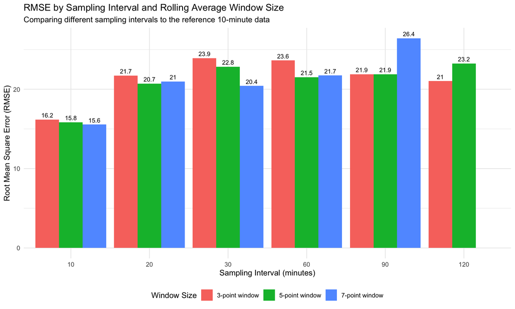

```r
# Prepare data for plotting
rmse_long <- rmse_by_interval %>%
  pivot_longer(
    cols = starts_with("mean_rmse"),
    names_to = "window_size",
    values_to = "rmse"
  ) %>%
  mutate(
    window_size = factor(window_size,
                         levels = c("mean_rmse_window_3", "mean_rmse_window_5", "mean_rmse_window_7"),
                         labels = c("3-point window", "5-point window", "7-point window"))
  )

# Plot RMSE by interval and window size
ggplot(rmse_long, aes(x = factor(interval_minutes), y = rmse, fill = window_size)) +
  geom_bar(stat = "identity", position = position_dodge(width = 0.9)) +
  geom_text(aes(label = round(rmse, 1)), position = position_dodge(width = 0.9),
            vjust = -0.5, size = 3) +
  labs(
    title = "RMSE by Sampling Interval and Rolling Average Window Size",
    subtitle = "Comparing different sampling intervals to the reference 10-minute data",
    x = "Sampling Interval (minutes)",
    y = "Root Mean Square Error (RMSE)",
    fill = "Window Size"
  ) +
  theme_minimal() +
  theme(
    legend.position = "bottom",
    axis.text.x = element_text(angle = 0)
  )
```

```r
# Save the figure
ggsave("figures/rmse_by_interval_rolling_avg.png", width = 10, height = 6)
```

## Visualizing Example Data with Rolling Averages

Let’s visualize a sample day to see how the different rolling averages compare to the actual data.

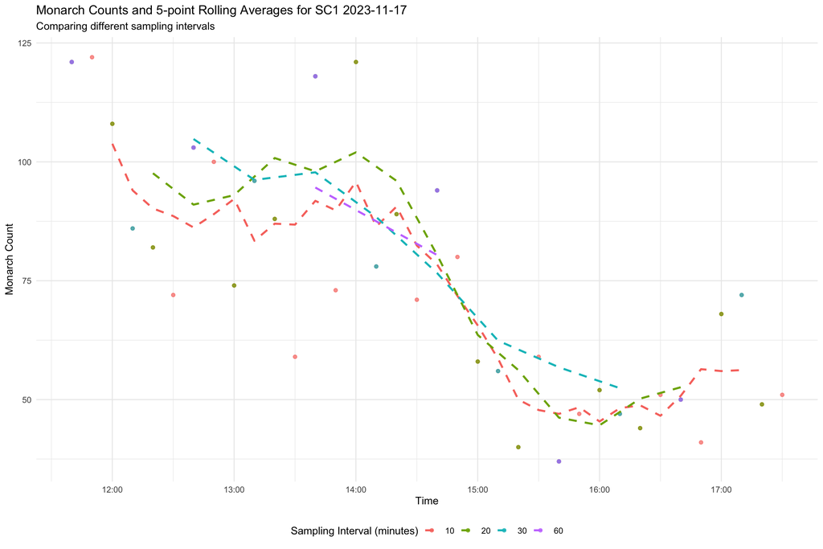

```r
# Select a single observation period for visualization
example_period <- unique(perm_data$observation_period)[1]

# Prepare data for the selected period with different intervals
example_data <- perm_data %>%
  filter(
    observation_period == example_period,
    interval_minutes %in% c(10, 20, 30, 60)
  ) %>%
  # Make sure we have one permutation per interval (use the first one)
  group_by(interval_minutes) %>%
  filter(permutation_number == min(permutation_number)) %>%
  ungroup() %>%
  # Calculate rolling averages
  group_by(interval_minutes) %>%
  arrange(timestamp) %>%
  mutate(
    roll_avg_5 = rollapplyr(count, width = 5, FUN = mean, fill = NA, align = "center")
  )

# Plot the example data
ggplot(example_data, aes(x = as_datetime(timestamp))) +
  geom_point(aes(y = count, color = factor(interval_minutes)), alpha = 0.7) +
  geom_line(aes(y = roll_avg_5, color = factor(interval_minutes)),
            linetype = "dashed", linewidth = 1) +
  labs(
    title = paste("Monarch Counts and 5-point Rolling Averages for", example_period),
    subtitle = "Comparing different sampling intervals",
    x = "Time",
    y = "Monarch Count",
    color = "Sampling Interval (minutes)"
  ) +
  scale_x_datetime(date_labels = "%H:%M") +
  theme_minimal() +
  theme(legend.position = "bottom")
```

```r
# Save the figure
ggsave("figures/example_rolling_avg_comparison.png", width = 12, height = 8)
```

## RMSE Distribution Across Permutations

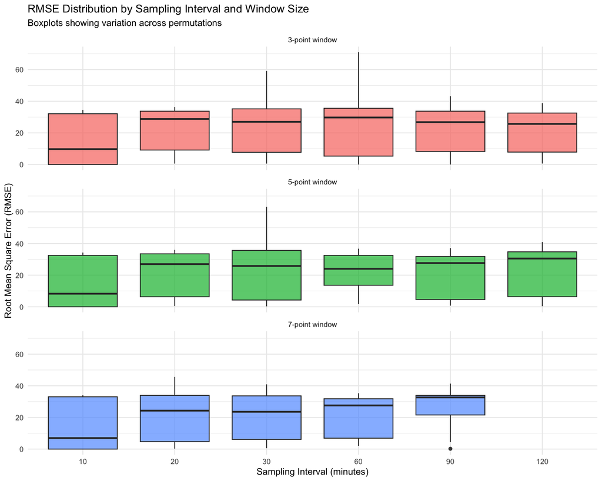

```r
# Prepare data for box plots
rmse_distribution <- rmse_results %>%
  pivot_longer(
    cols = starts_with("rmse_window"),
    names_to = "window_size",
    values_to = "rmse"
  ) %>%
  mutate(
    window_size = factor(window_size,
                         levels = c("rmse_window_3", "rmse_window_5", "rmse_window_7"),
                         labels = c("3-point window", "5-point window", "7-point window"))
  )

# Create boxplots to show RMSE distribution
ggplot(rmse_distribution, aes(x = factor(interval_minutes), y = rmse, fill = window_size)) +
  geom_boxplot(alpha = 0.7) +
  facet_wrap(~ window_size, ncol = 1) +
  labs(
    title = "RMSE Distribution by Sampling Interval and Window Size",
    subtitle = "Boxplots showing variation across permutations",
    x = "Sampling Interval (minutes)",
    y = "Root Mean Square Error (RMSE)",
    fill = "Window Size"
  ) +
  theme_minimal() +
  theme(legend.position = "none")
```

```r
# Save the figure
ggsave("figures/rmse_distribution_by_interval.png", width = 10, height = 8)
```

## Conclusion

This analysis investigates how different sampling intervals (using rolling averages as trend estimators) affect our ability to capture monarch count patterns. The RMSE metrics provide a quantitative measure of how well each sampling interval approximates the reference 10-minute data.

The results can help optimize future data collection efforts, potentially reducing sampling frequency while maintaining sufficient accuracy for trend analysis.